# STATS 369 Assignment 1 2022

Name: Yihao Wu

Due Date: 10 August 2022, at 22:00

# 1 Data

Under Modules | Data sets | Bike counts | Bike data for Assignment 1 on Canvas you have data on the number of people counted cycling in Auckland and the amount of rain.

# 2 Task

## 2.1 If you try to convert the cycle count data to tidy format (which you don’t have to do for this assignment, because it’s hard), what is the main obstacle you will encounter?

We got the daily counts for bicycles passing certain points in the Auckland area from 2016 to 2018, so the records of these locations could be a little bit different from year to year. When we combine these three data frames into a single data frame, we may have multiple names for the same counter. But we do not have any standard rules to approach it, and we do not know how to deal with it as well. Also, there are some columns that are entire `NA`. Therefore, it is very hard to convert the cycle count data into a tidy format.

## 2.2 Compute the total number of cyclists counted for each day, and a suitable summary of the rainfall for each day, in the same data frame. Include justification the rainfall sumary you use.

```r
## Choose the directory here which contain the three bike counter data files.
bike_files <- list.files("/Users/University\ of\ Auckland/Year\ 3/Semester\ 2/STATS\ 369/Assignment\ 1/Bikedata", pattern = ".csv", full = TRUE)

## Iterates over each element of `bike_files`, applying `read_csv` to each.
bike_data <- map(bike_files, read_csv)

## There are some columns that are entire `NA`: get rid of them with `select_if`.
notallNA <- function(x) !all(is.na(x))
## Apply the user defined function `notallNA` to each element of the list `bike_data`.
bike_data <- map(bike_data, select_if, notallNA)

## Try to `pivot_longer` for each data frame in `bike_data`.
bike_tidy <- map(bike_data, pivot_longer, values_to = "rider_count", names_to = "counter", -Date)
## Combine a list of data frames into a single data frame.
allbikes <- bind_rows(bike_tidy)

## Create a tibble with the number of active counters for each day.
active_allbikes <- allbikes %>%
  filter(!is.na(rider_count)) %>%
  count(Date) %>%
  rename(number_of_active_counters = n)

## Create a tibble with the total number of cyclists counted for each day.
allbikes_day <- allbikes %>%
  group_by(Date) %>%
  summarise(daily_rider_count = sum(rider_count, na.rm = TRUE)) %>%
  left_join(active_allbikes, by = "Date") %>%
  separate(col = Date, into = c("day of week", "day", "month", "year")) %>%
  mutate(day = as.numeric(day), year = as.numeric(year)) %>%
  mutate(month = case_when(month == "Jan" ~ 1, month == "Feb" ~ 2, month == "Mar" ~ 3, month == "Apr" ~ 4,
                           month == "May" ~ 5, month == "Jun" ~ 6, month == "Jul" ~ 7, month == "Aug" ~ 8,
                           month == "Sep" ~ 9, month == "Oct" ~ 10, month == "Nov" ~ 11, TRUE ~ 12))

allbikes_day
```

```
## # A tibble: 1,097 × 6
##    `day of week`   day month  year daily_rider_count number_of_active_counters
##    <chr>         <dbl> <dbl> <dbl>             <dbl>                     <int>
##  1 Fri               1     4  2016              8755                        28
##  2 Fri               1    12  2017             14252                        39
##  3 Fri               1     1  2016              1299                        28
##  4 Fri               1     7  2016              8993                        28
##  5 Fri               1     6  2018             12967                        40
##  6 Fri               1     9  2017             10871                        35
##  7 Fri              10     8  2018             12580                        41
##  8 Fri              10     2  2017             14562                        32
##  9 Fri              10     6  2016              6450                        28
## 10 Fri              10     3  2017              7361                        32
## # … with 1,087 more rows
## # ℹ Use `print(n = ...)` to see more rows
```

```r
## Import the rainfall datasets.
rain_files <- list.files("/Users/University\ of\ Auckland/Year\ 3/Semester\ 2/STATS\ 369/Assignment\ 1/Raindata", pattern = ".txt", full = TRUE)

rain_1617 <- rain_files[1] %>%
  read.table(header = TRUE, sep = ",", skip = 9, nrows = 35090)

rain_18 <- rain_files[2] %>%
  read.table(header = TRUE, sep = ",", skip = 9, nrows = 17304)

## Combine two datasets into a tibble.
allrains <- as_tibble(bind_rows(rain_1617, rain_18))

## Create a tibble with the total amount of precipitation for each day.
allrains_day <- allrains %>%
  group_by(Date.NZST.) %>%
  summarise(total_amount_mm = sum(Amount.mm., na.rm = TRUE) / 2) %>%
  separate(col = "Date.NZST.", into = c("year", "month", "day"), sep = c(4, 6)) %>%
  mutate(year = as.numeric(year), month = as.numeric(month), day = as.numeric(day))

allrains_day
```

```
## # A tibble: 1,097 × 4
##     year month   day total_amount_mm
##    <dbl> <dbl> <dbl>           <dbl>
##  1  2016     1     1           20.2
##  2  2016     1     2           19.2
##  3  2016     1     3            6.8
##  4  2016     1     4            0.05
##  5  2016     1     5            0
##  6  2016     1     6            0
##  7  2016     1     7            0
##  8  2016     1     8           36.6
##  9  2016     1     9            0.1
## 10  2016     1    10            0
## # … with 1,087 more rows
## # ℹ Use `print(n = ...)` to see more rows
```

```r
## Combine `allbikes_day` and `allrains_day` together.
bike_rainfall_day <- allbikes_day %>%
  inner_join(allrains_day, by = c("year", "month", "day")) %>%
  arrange(year, month, day)

dim(bike_rainfall_day)
```

```
## [1] 1096    7
```

```r
bike_rainfall_day
```

```
## # A tibble: 1,096 × 7
##    `day of week`   day month  year daily_rider_count number_of_active_…¹ total…²
##    <chr>         <dbl> <dbl> <dbl>             <dbl>               <int>   <dbl>
##  1 Fri               1     1  2016              1299                  28   20.2
##  2 Sat               2     1  2016              1030                  28   19.2
##  3 Sun               3     1  2016              7423                  28    6.8
##  4 Mon               4     1  2016             11956                  28    0.05
##  5 Tue               5     1  2016             10167                  28    0
##  6 Wed               6     1  2016             10387                  28    0
##  7 Thu               7     1  2016              9573                  28    0
##  8 Fri               8     1  2016              3535                  28   36.6
##  9 Sat               9     1  2016              8998                  28    0.1
## 10 Sun              10     1  2016             10429                  28    0
## # … with 1,086 more rows, and abbreviated variable names
## #   ¹number_of_active_counters, ²total_amount_mm
## # ℹ Use `print(n = ...)` to see more rows
```

```r
tail(bike_rainfall_day)
```

```
## # A tibble: 6 × 7
##   `day of week`   day month  year daily_rider_count number_of_active_c…¹ total…²
##   <chr>         <dbl> <dbl> <dbl>             <dbl>                <int>   <dbl>
## 1 Wed              26    12  2018              8314                   43       0
## 2 Thu              27    12  2018             12802                   43       0
## 3 Fri              28    12  2018             12102                   43       0
## 4 Sat              29    12  2018             11492                   43       0
## 5 Sun              30    12  2018             12271                   43       0
## 6 Mon              31    12  2018             10603                   43       0
## # … with abbreviated variable names ¹number_of_active_counters,
## #   ²total_amount_mm
```

The data frame `bike_rainfall_day` contains the total number of cyclists and the total amount of precipitation for each day from 2016 to 2018. For the rainfall summary statistic, I used the total amount of precipitation for each day. Such a summary statistic is commonly used to monitor the daily rainfall. But we have the hourly rainfall data from two different stations in Auckland, such as Albany (in North Auckland) and Mangere (in South Auckland), so I computed the total amount of precipitation for each station separately and took the average of them. It is an appropriate summary of the rainfall because it would be easier and more helpful to do further analysis between the number of cyclists and the amount of precipitation for each day in Auckland.

## 2.3 Draw suitable graphs to display how the number of cyclists varies over time, over season, over day of the week, and with rain.

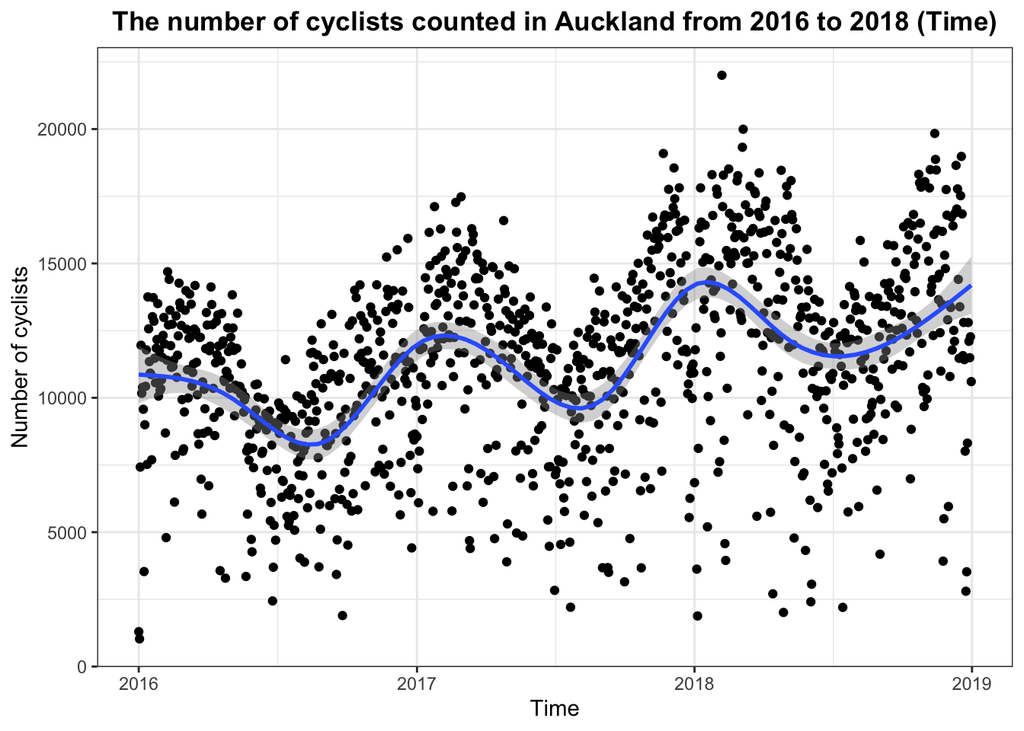

```r
## Modify the tibble `bike_rainfall_day` to get a new column called `date`.
bike_rainfall_day <- bike_rainfall_day %>%
  mutate(date = paste(day, month, year, sep = "-")) %>%
  mutate(date = as.Date(date, "%d-%m-%Y"))


## Draw a graphic to display the number of cyclists over time.
bike_rainfall_day %>%
  ggplot(aes(x = date, y = daily_rider_count)) +
  geom_point() +
  geom_smooth(method = "gam") +
  labs(x = "Time", y = "Number of cyclists",
       title = "The number of cyclists counted in Auckland from 2016 to 2018 (Time)") +
  theme_bw() +
  theme(plot.title = element_text(face = "bold", hjust = 0.5))
```

The plot shows the number of cyclists counted in Auckland from Jan 2016 to Dec 2018. In general, the number of cyclists seems to decrease in the first half year but increases each year after June or July or August (Winter). For each year, there were more cyclists in Summer than in Winter.

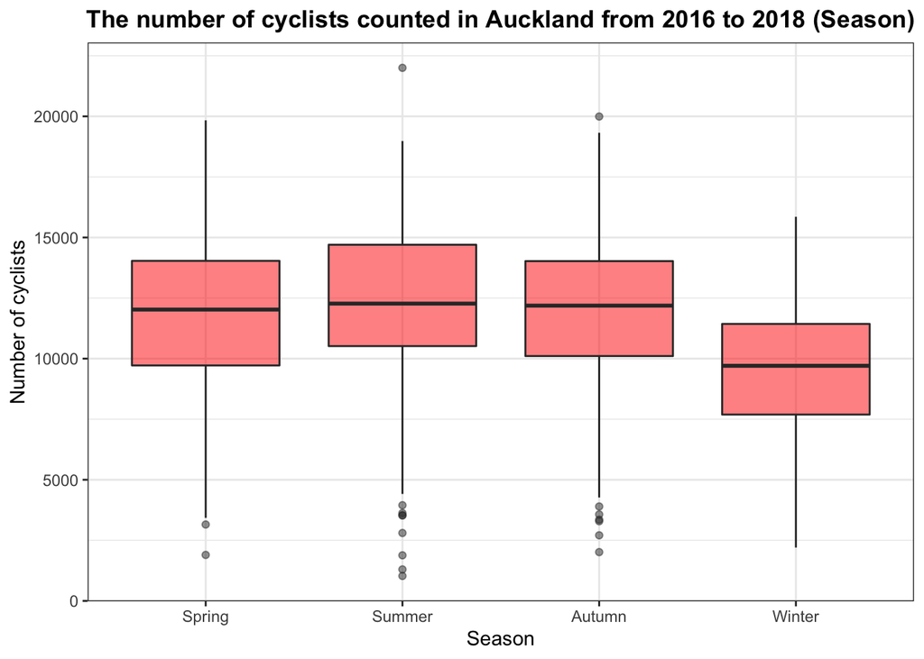

```r
## Create the tibble `bike_rainfall_season` with the factor variable called `season`.
y <- c("2016", "2017", "2018")
s <- c("Spring", "Summer", "Autumn", "Winter")
dow <- c("Mon", "Tue", "Wed", "Thu", "Fri", "Sat", "Sun")

bike_rainfall_season <- bike_rainfall_day %>%
  mutate(season = case_when(month == 9 | month == 10 | month == 11 ~ "Spring",
                            month == 12 | month == 1 | month == 2 ~ "Summer",
                            month == 3 | month == 4 | month == 5 ~ "Autumn",
                            TRUE ~ "Winter")) %>%
  mutate(season = factor(season, levels = s),
         `day of week` = factor(`day of week`, levels = dow),
         year_fac = factor(year, levels = y))


## Draw a graphic to display the number of cyclists over season.
bike_rainfall_season %>%
  ggplot(aes(x = season, y = daily_rider_count)) +
  geom_boxplot(fill = "red", alpha = 0.5) +
  labs(x = "Season", y = "Number of cyclists",
       title = "The number of cyclists counted in Auckland from 2016 to 2018 (Season)") +
  theme_bw() +
  theme(plot.title = element_text(face = "bold", hjust = 0.5))
```

The box plot indicates that there seem to have fewer cyclists in Winter than in other seasons, which is consistent with the first plot (comments above).

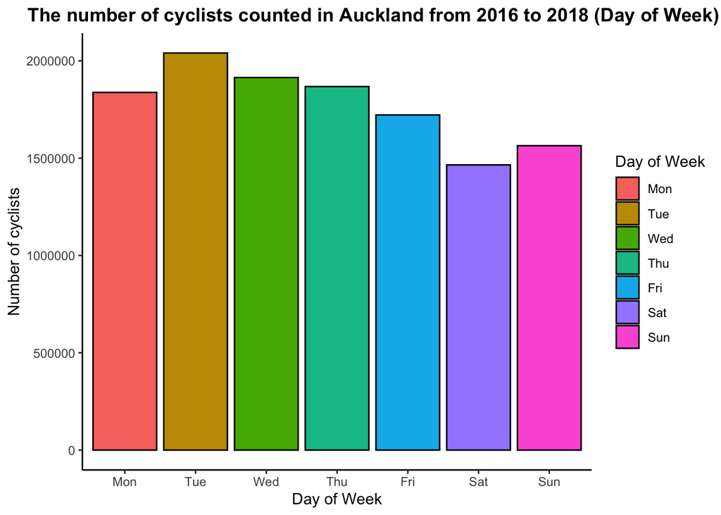

```r
## Draw a graphic to display the number of cyclists over day of the week.
bike_rainfall_season %>%
  group_by(`day of week`) %>%
  summarise(dow_count = sum(daily_rider_count)) %>%
  ggplot(aes(x = `day of week`, y = dow_count)) +
  geom_col(aes(fill = `day of week`), color = "black") +
  labs(x = "Day of Week", y = "Number of cyclists",
       title = "The number of cyclists counted in Auckland from 2016 to 2018 (Day of Week)") +
  guides(fill = guide_legend(title = "Day of Week")) +
  theme_classic() +
  theme(plot.title = element_text(face = "bold", hjust = 0.3))
```

Overall, the number of cyclists increases each week from Monday to Tuesday but decreases after Tuesday. Most people rode bikes on Tuesdays more than on other working days in Auckland. For weekends, there were more cyclists on Sunday.

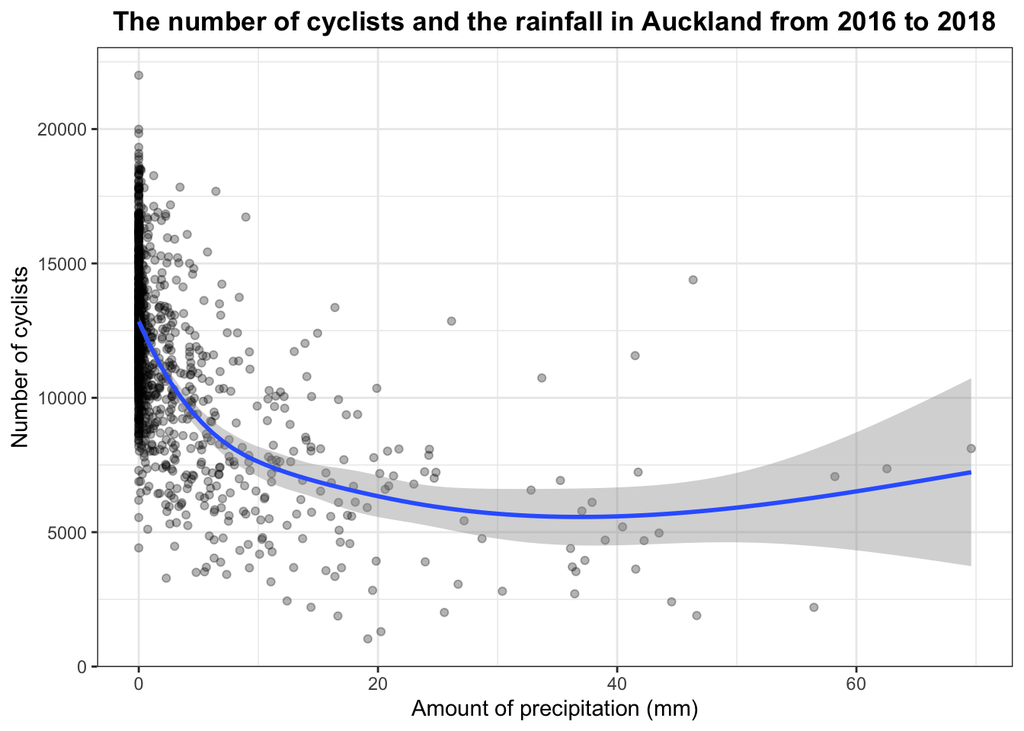

```r
## The scatter plot to display the number of cyclists with rain.
bike_rainfall_season %>%
  ggplot(aes(x = total_amount_mm, y = daily_rider_count)) +
  geom_point(alpha = 0.3) +
  geom_smooth(method = "gam") +
  labs(x = "Amount of precipitation (mm)", y = "Number of cyclists",
       title = "The number of cyclists and the rainfall in Auckland from 2016 to 2018") +
  theme_bw() +
  theme(plot.title = element_text(face = "bold", hjust = 0.5))
```

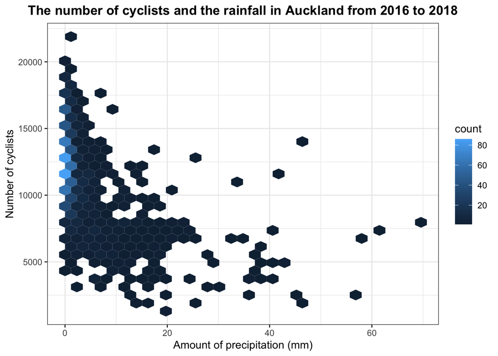

```r
## The hexagonal heatmap to display the number of cyclists with rain.
bike_rainfall_season %>%
  ggplot(aes(x = total_amount_mm, y = daily_rider_count)) +
  geom_hex() +
  labs(x = "Amount of precipitation (mm)", y = "Number of cyclists",
       title = "The number of cyclists and the rainfall in Auckland from 2016 to 2018") +
  theme_bw() +
  theme(plot.title = element_text(face = "bold", hjust = 0.5))
```

These two plots indicate a clear negative relationship between the number of cyclists and the amount of precipitation in Auckland from 2016 to 2018.

## 2.4 Fit a regression model to predict the number of cyclists from year, season, day of the week, and rain. You do not need to include interactions or transformation in the model, and results do not require cross-validation.

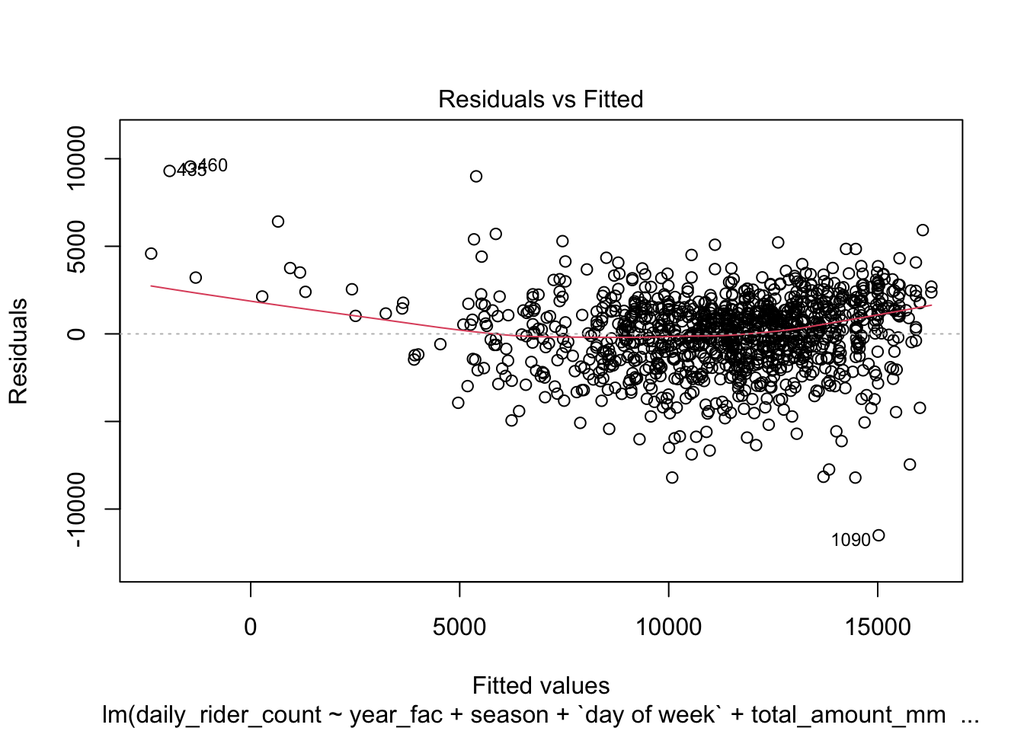

```r
cyclists.fit <- lm(daily_rider_count ~ year_fac + season + `day of week` + total_amount_mm +
                     number_of_active_counters, data = bike_rainfall_season)
plot(cyclists.fit, which = 1)
```

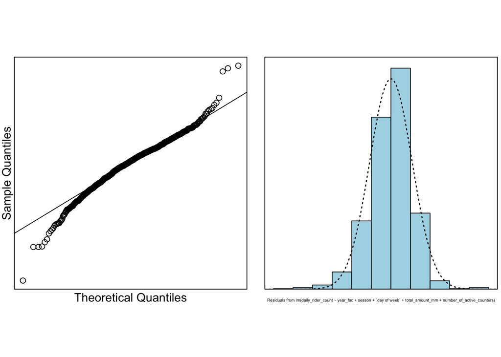

```r
normcheck(cyclists.fit)
```

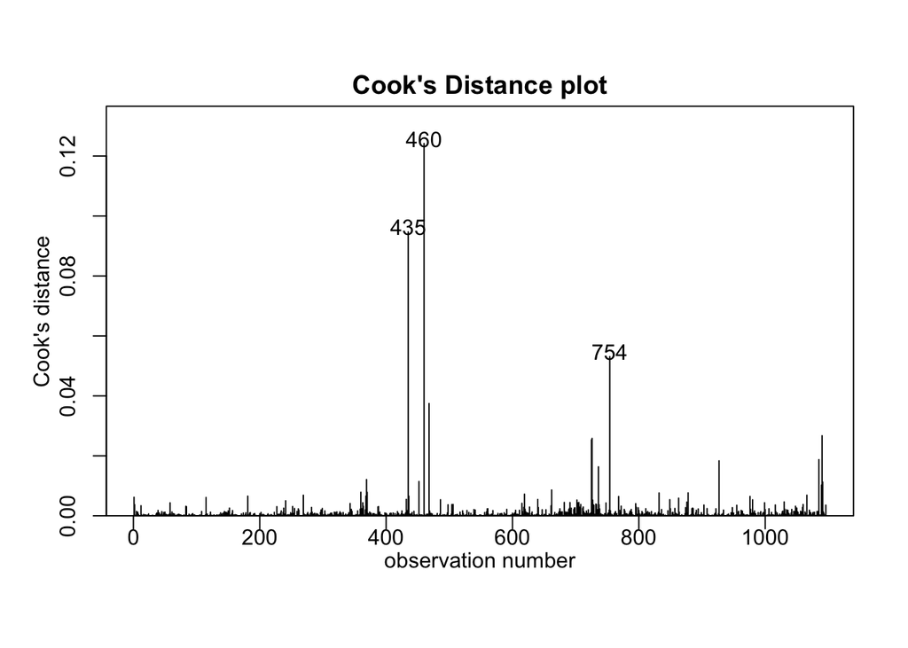

```r
cooks20x(cyclists.fit)
```

```r
summary(cyclists.fit)
```

```
##
## Call:
## lm(formula = daily_rider_count ~ year_fac + season + `day of week` +
##     total_amount_mm + number_of_active_counters, data = bike_rainfall_season)
##
## Residuals:
##      Min       1Q   Median       3Q      Max
## -11496.5  -1256.0    190.1   1350.0   9554.9
##
## Coefficients:
##                            Estimate Std. Error t value Pr(>|t|)
## (Intercept)                8874.943   1549.409   5.728 1.32e-08 ***
## year_fac2017               1395.978    285.442   4.891 1.16e-06 ***
## year_fac2018               2264.953    612.602   3.697 0.000229 ***
## seasonSummer                761.687    201.231   3.785 0.000162 ***
## seasonAutumn                597.481    235.324   2.539 0.011257 *
## seasonWinter              -1839.736    206.291  -8.918  < 2e-16 ***
## `day of week`Tue           1437.562    246.265   5.837 7.00e-09 ***
## `day of week`Wed            923.926    246.572   3.747 0.000188 ***
## `day of week`Thu            522.169    246.412   2.119 0.034310 *
## `day of week`Fri           -674.988    245.875  -2.745 0.006147 **
## `day of week`Sat          -2203.911    245.948  -8.961  < 2e-16 ***
## `day of week`Sun          -1560.954    245.957  -6.346 3.23e-10 ***
## total_amount_mm            -229.005      8.518 -26.885  < 2e-16 ***
## number_of_active_counters    68.463     49.801   1.375 0.169505
## ---
## Signif. codes:  0 '***' 0.001 '**' 0.01 '*' 0.05 '.' 0.1 ' ' 1
##
## Residual standard error: 2178 on 1082 degrees of freedom
## Multiple R-squared:  0.6085, Adjusted R-squared:  0.6038
## F-statistic: 129.4 on 13 and 1082 DF,  p-value: < 2.2e-16
```

```r
confint(cyclists.fit)
```

```
##                                 2.5 %     97.5 %
## (Intercept)                5834.75690 11915.1298
## year_fac2017                835.89500  1956.0607
## year_fac2018               1062.92957  3466.9760
## seasonSummer                366.84108  1156.5336
## seasonAutumn                135.73819  1059.2238
## seasonWinter              -2244.51165 -1434.9609
## `day of week`Tue            954.35154  1920.7734
## `day of week`Wed            440.11224  1407.7404
## `day of week`Thu             38.66972  1005.6689
## `day of week`Fri          -1157.43404  -192.5420
## `day of week`Sat          -2686.50046 -1721.3216
## `day of week`Sun          -2043.56154 -1078.3467
## total_amount_mm            -245.71827  -212.2908
## number_of_active_counters   -29.25557   166.1807
```

We fitted a simple linear regression `cyclists.fit` to predict the number of cyclists from year, season, day of the week, rain, and the number of active counters. The number of active counters on each day does not seem to have a significant impact on the number of cyclists because the **P-value** of this term is about $0.17$.

This model only explained about $61\%$ of the variation in the number of cyclists, so it is not a very good model for prediction.